# R per l’analisi statistica multivariata

Inferenza statistica e proprietà degli stimatori

In questa lezione ci occuperemo di inferenza statistica e studieremo le proprietà degli stimatori utilizzando **R**.

## Media e varianza campionaria

Supponiamo che $X_1,\dots,X_n$ siano delle variabili aleatorie **normali** indipendenti ed identicamente distribuite, aventi media $\mathbb{E}(X_1) = \mu$ e varianza $\sigma^2$, ovvero $X_i \overset{\text{iid}}{\sim} \text{N}(\mu, \sigma^2)$.

I valori $\mu$ e $\sigma^2$ sono ignoti e siamo interessati a stimarli.

## Un semplice studio di simulazione

Generiamo le osservazioni $x_1,\dots,x_n$ da una distribuzione Gaussiana $\text{N}(10, 16)$.

```r
set.seed(100)
n <- 20
mu <- 10
sigma2 <- 16

x <- rnorm(n, mean = mu, sd = sqrt(sigma2))
```

Un possibile stimatore per la media $\mu$ è la media campionaria, ovvero

$$\bar{X} = \frac{1}{n}\sum_{i=1}^nX_i.$$
In **R** possiamo ottenere la stima puntuale come segue

```r
x_bar <- mean(x) # Media campionaria dei dati x_1,...,x_n
x_bar
[1] 10.43147
```

Poichè abbiamo osservato solamente un campione $x_1,\dots,x_n$, disponiamo anche di un’unica stima $\bar{x}$ per la media $\mu$. Se tuttavia osservassimo degli ulteriori dataset, otterremmo dei valori della media aritmetica leggermente diversi. Come noto, la distribuzione dello stimatore $\bar{X}$ è pari a

$$\bar{X} \sim \text{N}\left(\mu, \frac{\sigma^2}{n}\right),$$
ovvero in questo caso $\bar{X} \sim \text{N}(10, 0.8)$. Per chiarire questo concetto, simuliamo $R = 10000$ nuovi dataset di dimensione $n = 20$ e calcoliamo la media aritmetica in ciascun caso.

```r
set.seed(156)
R <- 10^4
X_bar <- replicate(R, mean(rnorm(n = n, mean = mu, sd = sqrt(sigma2))))

head(X_bar)
[1]  9.939276 10.262788  9.598163 10.633335  8.713862 10.339131
```

Il vettore `X_bar` contiene le medie aritmetiche di ciascun dataset. Confrontiamo quindi l’istogramma degli stimatori con la distribuzione teorica, utilizzando i comandi seguenti.

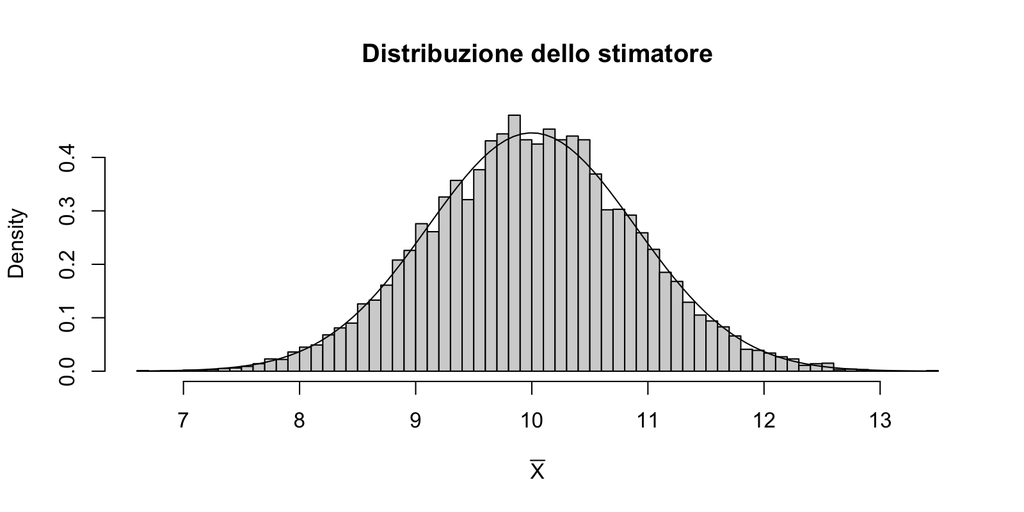

```r
hist(X_bar,
  freq = FALSE,
  main = "Distribuzione dello stimatore", xlab = expression(bar(X)),
  breaks = 50
)
curve(dnorm(x, mean = mu, sd = sqrt(sigma2 / n)), add = TRUE)
```

### Varianza campionaria

Ripetiamo quindi lo stesso esperimento con la varianza campionaria (corretta), che è definita come

$$S^2 = \frac{1}{n-1}\sum_{i=1}^n (X_i - \bar{X})^2.$$
Come visto nelle lezioni precedenti, possiamo ottenere la stima puntuale della varianza $\sigma^2$ come segue

```r
s2 <- var(x) # Varianza campionaria (corretta) dei dati x_1,...,x_n
s2
[1] 8.26136
```

Il valore ottenuto $s^2$ si discosta non poco dal valore vero $\sigma^2 = 16$. Questo è tuttavia compatibile con la variabilità dello stimatore $S^2$, la cui distribuzione è

$$S^2 \sim \frac{\sigma^2}{n-1}\chi^2_{n-1}, \qquad \text{ovvero} \qquad S^2 \sim \text{Ga}\left(\frac{n-1}{2}, \frac{n-1}{2 \sigma^2} \right).$$
Simuliamo quindi $R = 10000$ nuovi dataset di dimensione $n = 20$ e calcoliamo la varianza campionaria in ciascun caso.

```r
set.seed(156)
R <- 10^4
S2 <- replicate(R, var(rnorm(n = n, mean = mu, sd = sqrt(sigma2))))

head(S2)
[1] 10.67897 12.47207 14.04570 20.53417 17.15042 16.23114
```

Il vettore `S2` contiene le varianze campionarie di ciascun dataset. Confrontiamo quindi l’istogramma degli stimatori con la distribuzione teorica

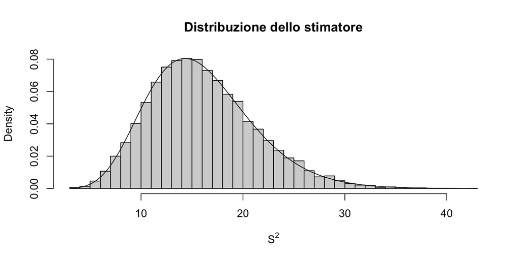

```r
hist(S2,
  freq = FALSE,
  main = "Distribuzione dello stimatore", xlab = expression(S^2),
  breaks = 50
)
curve(dgamma(x, (n - 1) / 2, (n - 1) / (2 * sigma2)), add = TRUE)
```

## Intervalli di confidenza

Se le osservazioni sono realizzazioni di variabili normali, allora un intervallo di confidenza di livello $1 - \alpha$ per la media è il seguente:

$$\text{IC}({\bf x}) = \left[\bar{x} - t_{n - 1, 1 - \alpha/2}\sqrt{\frac{s^2}{n}}, \bar{x} + t_{n - 1, 1 - \alpha/2}\sqrt{\frac{s^2}{n}}\right],$$
dove ${ \bf x} = (x_1,\dots,x_n)$ e $t_{p, n-1}$ è il quantile $p$ di una distribuzione $t$ di Student con $n-1$ gradi di libertà. Fissando $\alpha = 0.05$, in **R** possiamo quindi calcolare

```r
alpha <- 0.05
qt(1 - alpha / 2, n - 1)
[1] 2.093024
```

Questo implica che l’intervallo di confidenza al $95\%$ per la media è pari a:

```r
CI <- mean(x) + c(-1, 1) * qt(1 - alpha / 2, n - 1) * sqrt(var(x) / n)
CI
[1]  9.086274 11.776663
```

Per costruzione, la probabilità che un intervallo di confidenza $\text{IC}({\bf X})$ contenga il vero valore $\mu$ è pari a $1 - \alpha$. In altri termini:

$$\mathbb{P}(\mu \in \text{IC}({\bf X})) = 1-\alpha.$$
Vogliamo verificare questo fatto tramite simulazione. Si faccia attenzione che $\mu$ non è affatto casuale, ma è anzi pari a $10$ nel nostro esempio! L’aleatorietà dipende esclusivamente dai dati.

In altri termini, se simulassimo vari dataset e in ciascun caso calcolassimo il corrispondente intervallo di confidenza per la media, otterremmo che la frazione di volte che tali intervalli contengono $\mu = 10$ tende a $1 - \alpha$.

La funzione seguente controlla se il valore $\mu$ è contenuto o meno in $\text{IC}({\bf x})$.

```r
is_mu_in_CI <- function(x, mu) {
  CI <- mean(x) + c(-1, 1) * qt(1 - alpha / 2, n - 1) * sqrt(var(x) / n)
  (mu >= CI[1]) & (mu <= CI[2])
}

is_mu_in_CI(x = x, mu = mu)
[1] TRUE
```

Pertanto, possiamo condurre il seguente studio di simulazione per la verificare la cosiddetta *copertura* di un intervallo di confidenza.

```r
set.seed(500)
y <- replicate(R, is_mu_in_CI(rnorm(n = n, mean = mu, sd = sqrt(sigma2)), mu = mu))

mean(y)
[1] 0.9515
```

## Distorsione

Sia $\hat{\theta}_n = \hat{\theta}({\bf X})$ uno stimatore per il parametro $\theta$ in un modello statistico parametrico, il cui vero valore, normalmente ignoto, è $\theta$. Chiamiamo distorsione il seguente valore atteso

$$\text{Distorsione} = \mathbb{E}(\hat{\theta}_n - \theta).$$
Possiamo quindi calcolare la distorsione di un determinato stimatore tramite simulazione, sfruttando la legge dei grandi numeri. Ad esempio, si supponga che $X_1,\dots,X_n$ sono variabili aleatorie iid distribuite come un normale di media $\mathbb{E}(X_1) = 0$ e varianza $\sigma^2 = 16$, con $n = 20$.

Vogliamo quindi calcolare tramite simulazione la distorsione dei seguenti stimatori della varianza

$$S^2_1 = \frac{1}{n}\sum_{i=1}^n(X_i - \bar{X})^2, \quad S^2_2 = \frac{1}{n -1}\sum_{i=1}^n(X_i - \bar{X})^2,$$

$$S^2_3 = \frac{1}{n}\sum_{i=1}^nX_i^2, \quad S_4 = \frac{1}{n+1}\sum_{i=1}^n(X_i - \bar{X})^2.$$

```r
set.seed(520)
R <- 10^5
n <- 20
mu <- 0
sigma2 <- 16

# Definisco le funzioni che calcolano gli stimatori
var1 <- function(x) mean(x^2) - mean(x)^2
var2 <- function(x) var(x) # Coincide con la definizione di R
var3 <- function(x) mean(x^2)
var4 <- function(x) (length(x) - 1) / (length(x) + 1) * var(x) # Coincide con la definizione di R

# Esecuzione della simulazione
S2_1 <- replicate(R, var1(rnorm(n = n, mean = mu, sd = sqrt(sigma2))))
S2_2 <- replicate(R, var2(rnorm(n = n, mean = mu, sd = sqrt(sigma2))))
S2_3 <- replicate(R, var3(rnorm(n = n, mean = mu, sd = sqrt(sigma2))))
S2_4 <- replicate(R, var4(rnorm(n = n, mean = mu, sd = sqrt(sigma2))))

# Distorsioni (approssimate)
round(mean(S2_1 - sigma2), 2)
[1] -0.85
round(mean(S2_2 - sigma2), 2)
[1] 0
round(mean(S2_3 - sigma2), 2)
[1] -0.03
round(mean(S2_4 - sigma2), 2)
[1] -1.56
```

## Errore quadratico medio

L’errore quadratico medio di uno stimatore $\hat{\theta}_n = \hat{\theta}({ \bf X})$ è definito come segue

$$\text{Errore quadratico medio} = \mathbb{E}\{(\hat{\theta}_n - \theta)^2\}.$$
Siamo interessati a valutare l’errore quadratico degli stimatori $S_1^2, S_2^2, S_3^2, S_4^2$ calcolati al punto precedente utilizzando le quantità appena calcolate. Pertanto, è sufficiente usare il seguente codice

```r
# Errore quadratico medio (approssimato)
mean((S2_1 - sigma2)^2)
[1] 24.96644
mean((S2_2 - sigma2)^2)
[1] 27.09368
mean((S2_3 - sigma2)^2)
[1] 25.40207
mean((S2_4 - sigma2)^2)
[1] 24.36703
```

Da questi risultati concludiamo che lo stimatore $S^2_4$ sembra essere quello preferibile in termini di errore quadratico medio, sebbene si tratti di uno stimatore distorto.

## Consistenza di uno stimatore

Siano $X_1,\dots,X_n$ delle variabili aleatorie iid da una distribuzione uniforme in $(0,\theta)$, dove $\theta > 0$ è un parametro ignoto. La stima di massima verosimiglianza in questo caso è pari a

$$\hat{\theta}_n = \max\{X_1,\dots,X_n\}.$$
Si può dimostrare (fatelo per esercizio!) che lo stimatore è consistente, ovvero vale che
$$\hat{\theta}_n \overset{p}{\longrightarrow} \theta.$$
Per visualizzare questa proprietà tramite simulazione, possiamo procedere come segue, sotto l’ipotesi che $\theta = 40$.

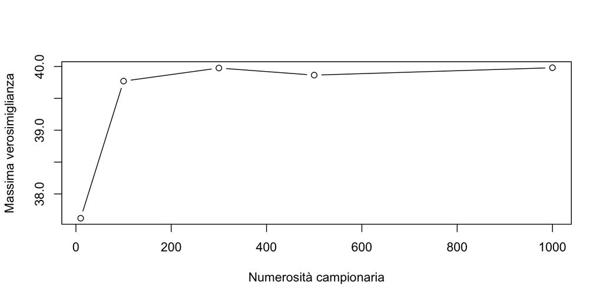

```r
theta0 <- 40

# Numerosità campionarie
nn <- c(10, 100, 300, 500, 1000)

# Stime di massima verosimiglianza
set.seed(123)
theta_hat <- c(
  max(runif(nn[1], min = 0, max = theta0)),
  max(runif(nn[2], min = 0, max = theta0)),
  max(runif(nn[3], min = 0, max = theta0)),
  max(runif(nn[4], min = 0, max = theta0)),
  max(runif(nn[5], min = 0, max = theta0))
)

plot(nn, theta_hat,
  type = "b",
  xlab = "Numerosità campionaria",
  ylab = "Massima verosimiglianza"
)
```

Le stime di massima verosimiglianza pertanto si avvicinano in misura sempre maggiore al valore $\theta = 40$, al netto di alcune oscillazioni casuali.

## Teorema del limite centrale

Il teorema del limite centrale, in una delle sue versioni più elementari, afferma che se $X_1,\dots,X_n$ sono delle variabili aleatorie indipendenti di media $E(X_1) = \mu$ e varianza $\sigma^2 < \infty$, allora vale che

$$\frac{\bar{X} - \mu}{\sigma/\sqrt{n}} = \frac{\bar{X} - E(\bar{X})}{\text{var}(\bar{X})^{1/2}} \overset{\text{d}}{\longrightarrow} \text{N}(0,1).$$
Prendiamo come esempio delle variabili esponenziali indipendenti $X_1,\dots,X_n$ di parametro $\lambda$, la cui media è $\mathbb{E}(X_1) = 1/\lambda$ e varianza $\sigma^2 = 1/\lambda^2$. Il teorema del limite centrale afferma che

$$Z_n = \lambda \sqrt{n} ( \bar{X} - 1/\lambda) \overset{\text{d}}{\longrightarrow} \text{N}(0,1), \qquad n \rightarrow \infty.$$
Per verificare empiricamente questa proprietà, ad esempio per $\lambda = 3$, possiamo simulare varie volte la variabile aleatoria $Z_n$ per valori di $n$ estremamente elevati e verificare che la sua distribuzione è “circa” quella di una normale standard.

```r
set.seed(156)

n <- 10^4 # Numerosità campionaria elevata
R <- 10^4 # Numero di simulazioni effettuate
lambda <- 3

# Estrazioni casuali da una variabile aleatoria Z_n
Z_n <- replicate(R, lambda * sqrt(n) * (mean(rexp(n = n, rate = lambda)) - 1 / lambda))
```

Una volta simulati i valori dalla variabile $Z_n$, la possiamo rappresentare graficamente

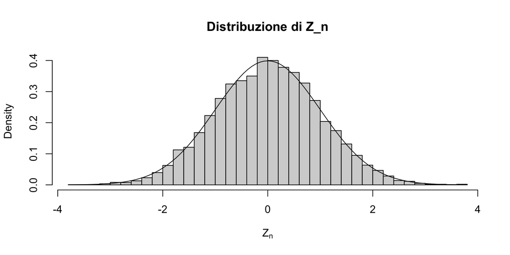

```r
hist(Z_n,
  freq = FALSE,
  main = "Distribuzione di Z_n", xlab = expression(Z[n]),
  breaks = 50
)
curve(dnorm(x, mean = 0, sd = 1), add = TRUE)
```

### I risultati asintotici sono validi solamente per $n$ “elevato”

Non tutti i valori di $n$ conducono ad una distribuzione di $Z_n$ indistinguibile da una distribuzione normale standard. Per esempio, si consideri il caso $n = 5$

```r
set.seed(156)

n <- 5 # Numerosità campionaria bassa
R <- 10^4 # Numero di simulazioni effettuate
lambda <- 3

# Estrazioni casuali da una variabile aleatoria Z_n
Z_n <- replicate(R, lambda * sqrt(n) * (mean(rexp(n = n, rate = lambda)) - 1 / lambda))
```

Il grafico successivo illustra un caso in cui l’approssimazione normale non sembra essere molto buona.

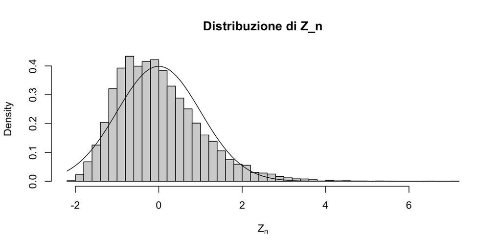

```r
hist(Z_n,
  freq = FALSE,
  main = "Distribuzione di Z_n", xlab = expression(Z[n]),
  breaks = 50
)
curve(dnorm(x, mean = 0, sd = 1), add = TRUE)
```

## QQ-plot

Un modo differente per verificare empiricamente se la distribuzione di una variabile $X$ è “simile” a quella di una Gaussiana, è tramite il cosiddetto **QQ-plot**. In pratica, si confrontano in un diagramma a dispersione i quantili empirici con i quantili teorici, ovvero

$$\mathcal{Q}_p = \text{(Quantili empirici)}, \quad \text{ vs } \quad z_p = \text{(Quantili teorici della normale standard)}.$$
su una griglia di valori $p$ di lunghezza $n$.

Innanzitutto, generiamo dei dati fittizi e la la griglia di valori $p$.

```r
set.seed(123)
n <- 50
x <- rnorm(n, mean = 10, sd = 5)

p <- ppoints(n) # Comando che genera una griglia di valori p
p
 [1] 0.01 0.03 0.05 0.07 0.09 0.11 0.13 0.15 0.17 0.19 0.21 0.23 0.25 0.27 0.29 0.31 0.33 0.35 0.37
[20] 0.39 0.41 0.43 0.45 0.47 0.49 0.51 0.53 0.55 0.57 0.59 0.61 0.63 0.65 0.67 0.69 0.71 0.73 0.75
[39] 0.77 0.79 0.81 0.83 0.85 0.87 0.89 0.91 0.93 0.95 0.97 0.99
```

Calcoliamo quindi i quantili teorici e quelli empirici come segue:

```r
z_p <- qnorm(p) # Quantili teorici della normale standard
Q_p <- quantile(x, probs = p, type = 5) # Quantili empirici dei dati
```

Il cosiddetto **QQ-plot** si ottiene quindi con i comandi seguenti. In caso i dati assomiglino ad una normale, allora i valori dovrebbero essere allineati lungo una retta.

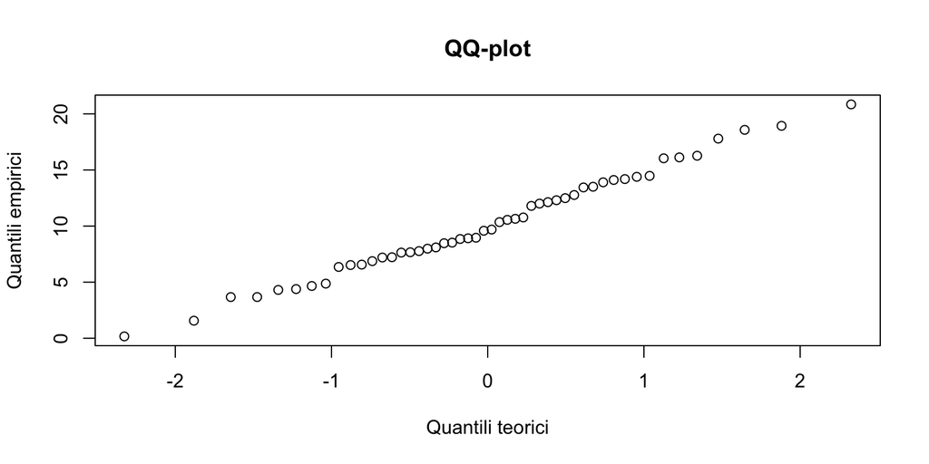

```r
plot(z_p, Q_p, main = "QQ-plot", xlab = "Quantili teorici", ylab = "Quantili empirici")
```

In **R** in realtà esiste un comando che svolge direttamente queste operazioni per noi, ovvero

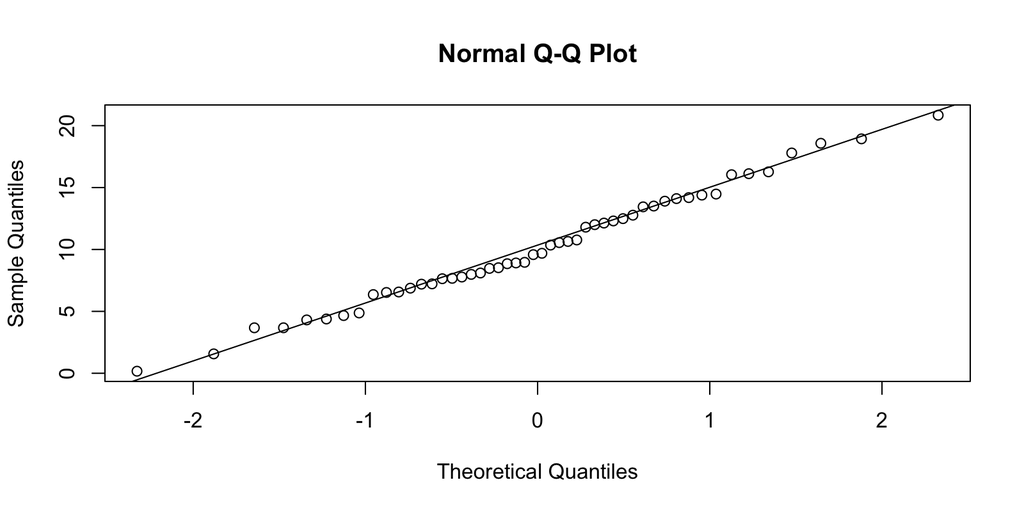

```r
qqnorm(x) # Grafico ottenuto in precedenza
qqline(x, qtype = 5) # Aggiunta della retta "teorica"
```

Come si può leggere dalla documentazione, `qqline` aggiunge la retta passante per i punti $(z_{0.25},\mathcal{Q}_{0.25})$ e $(z_{0.75},\mathcal{Q}_{0.75})$, che può essere considerata una versione robusta della retta ai minimi quadrati.

### La funzione `qqnorm` per dati non gaussiani

Se i dati non provengono da una distribuzione normale, allora il **QQ-plot** è in grado segnalarcelo.

Prendiamo in considerazione delle variabili aleatorie aventi distribuzione esponenziale di parametro $\lambda = 10$.

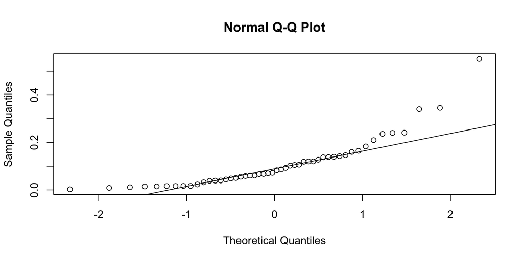

```r
set.seed(150)
x <- rexp(n, rate = 10) # Genero n osservazioni esponenziali indipendenti

## QQ-plot
qqnorm(x)
qqline(x)
```

Questo **QQ-plot** evidenza chiaramente uno scostamente dalla distribuzione gaussiana, dato che i punti sono ben distanti dalla linea disegnata da `qqline`.

### Nota a margine

Supponiamo di non conoscere il funzionamento di una funzione, ad esempio `qqline`.

Per conoscerne il funzionamento preciso, è possibile scriverla nel terminale, il quale restituirà la sua definizione.

```r
qqline
function (y, datax = FALSE, distribution = qnorm, probs = c(0.25,
    0.75), qtype = 7, ...)
{
    stopifnot(length(probs) == 2, is.function(distribution))
    y <- quantile(y, probs, names = FALSE, type = qtype, na.rm = TRUE)
    x <- distribution(probs)
    if (datax) {
        slope <- diff(x)/diff(y)
        int <- x[1L] - slope * y[1L]
    }
    else {
        slope <- diff(y)/diff(x)
        int <- y[1L] - slope * x[1L]
    }
    abline(int, slope, ...)
}
<bytecode: 0x7fa632946dc0>
<environment: namespace:stats>
```

## Normalità asintotica degli stimatori

Supponiamo che $\hat{\theta}_n = \hat{\theta}({ \bf X })$ sia lo stimatore di massima verosimiglianza per un modello parametrico $f(x; \theta)$ il cui vero valore è $\theta$.

Se i dati sono variabili aleatori iid da $f(x;\theta)$, sotto opportune condizioni, lo stimatore di massima verosimiglianza è consistente, ovvero: $\hat{\theta}_n \overset{p}{\longrightarrow} \theta$. Inoltre, sotto opportune condizioni di regolarità vale che

$$\sqrt{n}\frac{\hat{\theta}_n - \theta}{i_1(\hat{\theta}_n)^{-1/2}} \overset{d}{\longrightarrow} N(0,1), \qquad n \rightarrow \infty.$$
dove $i_1(\theta)$ rappresenta l’informazione attesa del modello $f(x;\theta)$, ovvero

$$i_1(\theta) = \mathbb{E}\left\{\left(\frac{\partial}{\partial \theta}\log{f(X;\theta)}\right)^2\right\} = - \mathbb{E}\left(\frac{\partial^2}{\partial \theta^2}\log{f(X;\theta)}\right).$$

### Il modello di Bernoulli

Siano $X_i \overset{\text{iid}}{\sim} \text{Ber}(\theta)$ per $i=1,\dots,n$ delle variabili aleatorie indipendenti ed identicamente distribuite. Lo stimatore di massima verosimiglianza è quindi pari a

$$\hat{\theta}_n = \frac{1}{n}\sum_{i=1}^nX_i = \frac{(``\text{numero di successi}")}{n}$$

Inoltre, si può dimostrare che $\mathcal{i_1}(\theta) = \{\theta(1 - \theta)\}^{-1}$, da cui si ottiene che

$$Z_n = \sqrt{n}\frac{\hat{\theta}_n - \theta}{\sqrt{\hat{\theta}_n(1 - \hat{\theta}_n)}} \overset{d}{\longrightarrow} N(0,1), \qquad n \rightarrow \infty.$$
Vogliamo verificare empiricamente questa proprietà in **R**, usando $n = 500$ e per $\theta = 0.5$.

```r
n <- 500
theta <- 0.5
R <- 10^4


Z_n_sample <- function(n, theta) {
  theta_n <- rbinom(1, n, prob = theta) / n
  # Comando equivalente: come mai?
  # theta_n <- sum(rbinom(n, 1, prob = theta)) / n.

  # Calcolo un singolo valore di Z_n
  sqrt(n) * (theta_n - theta) / sqrt(theta_n * (1 - theta_n))
}


# Effettuo la simulazione
set.seed(100)
Z_n <- replicate(R, Z_n_sample(n, theta))
```

Possiamo quindi utilizzare i metodi precedentemente introdotti per verificare quanto $Z_n$ sia vicino ad una normale standard.

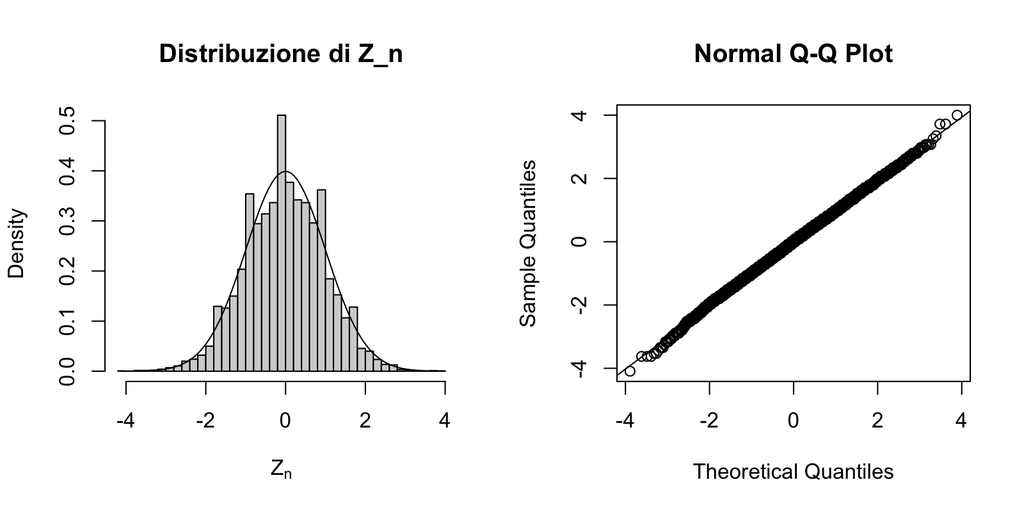

```r
par(mfrow = c(1, 2)) # Divido il pannello in due parti

# Confronto istogramma / densità teorica
hist(Z_n,
  freq = FALSE,
  main = "Distribuzione di Z_n", xlab = expression(Z[n]),
  breaks = 50
)
curve(dnorm(x, mean = 0, sd = 1), add = TRUE)

# QQ-plot
qqnorm(Z_n)
qqline(Z_n)
```

Dai grafici precedenti si evince che la distribuzione asintotica di $Z_n$ è sostanzialmente indistinguibile da quella di una distribuzione normale standard.